# Practical Machine Language

@drktjones

October 25, 2015

# Background

Using devices such as Jawbone Up, Nike FuelBand, and Fitbit it is now possible to collect a large amount of data about personal activity relatively inexpensively. These type of devices are part of the quantified self movement – a group of enthusiasts who take measurements about themselves regularly to improve their health, to find patterns in their behavior, or because they are tech geeks. One thing that people regularly do is quantify how much of a particular activity they do, but they rarely quantify how well they do it.

In this project, my goal will be to use data from accelerometers on the belt, forearm, arm, and dumbell of 6 participants. They were asked to perform barbell lifts correctly and incorrectly in 5 different ways. More information is available from the website here: http://groupware.les.inf.puc-rio.br/har (see the section on the Weight Lifting Exercise Dataset).

The training data for this project are available here: https://d396qusza40orc.cloudfront.net/predmachlearn/pml-training.csv

The test data are available here:  
https://d396qusza40orc.cloudfront.net/predmachlearn/pml-testing.csv

The goal of this project is to predict the manner in which they did the exercise using the “classe” variable in the training set. Details describing how I built the model, how I used cross validation, what I think the expected out of sample error is, and why I made the choices I did. I also use your prediction model to predict 20 different test cases.

# Model Building

My first step was to load the data, examine the data, and load relevant libraries used in these analyses.

```r
library(caret)
```

```r
library(rpart)
library(rpart.plot)
library(ggplot2)

set.seed(32343)

dat_train <- read.csv(url("https://d396qusza40orc.cloudfront.net/predmachlearn/pml-training.csv"),
                      na.strings=c("", "NA"))
dat_test <- read.csv(url("https://d396qusza40orc.cloudfront.net/predmachlearn/pml-testing.csv"),
                     na.strings=c("", "NA"))

dim(dat_train)
```

```
## [1] 19622   160
```

```r
dim(dat_test)
```

```
## [1]  20 160
```

Next, I removed variables that had one distinct value or near zero variance in order to obtain a better prediction. I also removed variables with missing data. I decided against imputing missing variables. Finally, I removed the first 6 columns of the data frames because I did not want to use these in the prediction given the structure of these data.

```r
nsv <- nearZeroVar(dat_train, saveMetrics = TRUE)
head(nsv)
```

```
##                      freqRatio percentUnique zeroVar   nzv
## X                     1.000000  100.00000000   FALSE FALSE
## user_name             1.100679    0.03057792   FALSE FALSE
## raw_timestamp_part_1  1.000000    4.26562022   FALSE FALSE
## raw_timestamp_part_2  1.000000   85.53154622   FALSE FALSE
## cvtd_timestamp        1.000668    0.10192641   FALSE FALSE
## new_window           47.330049    0.01019264   FALSE  TRUE
```

```r
dat_train1 <- dat_train[names(dat_train) %in%
                                 row.names(nsv[nsv$zeroVar==FALSE & nsv$nzv==FALSE,])]
dat_test1 <- dat_test[names(dat_test) %in%
                               c(row.names(nsv[nsv$zeroVar==FALSE & nsv$nzv==FALSE,]),
                                 "problem_id")]

ncol(dat_train1); ncol(dat_test1)
```

```
## [1] 117
```

```
## [1] 117
```

```r
names(dat_train1)
```

```
##   [1] "X"                        "user_name"
##   [3] "raw_timestamp_part_1"     "raw_timestamp_part_2"
##   [5] "cvtd_timestamp"           "num_window"
##   [7] "roll_belt"                "pitch_belt"
##   [9] "yaw_belt"                 "total_accel_belt"
##  [11] "kurtosis_roll_belt"       "kurtosis_picth_belt"
##  [13] "skewness_roll_belt"       "skewness_roll_belt.1"
##  [15] "max_roll_belt"            "max_picth_belt"
##  [17] "max_yaw_belt"             "min_roll_belt"
##  [19] "min_pitch_belt"           "min_yaw_belt"
##  [21] "amplitude_roll_belt"      "amplitude_pitch_belt"
##  [23] "var_total_accel_belt"     "avg_roll_belt"
##  [25] "stddev_roll_belt"         "var_roll_belt"
##  [27] "avg_pitch_belt"           "stddev_pitch_belt"
##  [29] "var_pitch_belt"           "avg_yaw_belt"
```

[output cut: 44 more lines]

```r
trainmiss <- apply(dat_train1,2,function(x) {sum(is.na(x))})
dat_train2 <- dat_train1[,which(trainmiss == 0)]

testmiss <- apply(dat_test1,2,function(x) {sum(is.na(x))})
dat_test2 <- dat_test1[,which(testmiss == 0)]
ncol(dat_train2); ncol(dat_test2)
```

```
## [1] 59
```

```
## [1] 59
```

```r
names(dat_train2)
```

```
##  [1] "X"                    "user_name"            "raw_timestamp_part_1"
##  [4] "raw_timestamp_part_2" "cvtd_timestamp"       "num_window"
##  [7] "roll_belt"            "pitch_belt"           "yaw_belt"
## [10] "total_accel_belt"     "gyros_belt_x"         "gyros_belt_y"
## [13] "gyros_belt_z"         "accel_belt_x"         "accel_belt_y"
## [16] "accel_belt_z"         "magnet_belt_x"        "magnet_belt_y"
## [19] "magnet_belt_z"        "roll_arm"             "pitch_arm"
## [22] "yaw_arm"              "total_accel_arm"      "gyros_arm_x"
## [25] "gyros_arm_y"          "gyros_arm_z"          "accel_arm_x"
## [28] "accel_arm_y"          "accel_arm_z"          "magnet_arm_x"
## [31] "magnet_arm_y"         "magnet_arm_z"         "roll_dumbbell"
## [34] "pitch_dumbbell"       "yaw_dumbbell"         "total_accel_dumbbell"
## [37] "gyros_dumbbell_x"     "gyros_dumbbell_y"     "gyros_dumbbell_z"
## [40] "accel_dumbbell_x"     "accel_dumbbell_y"     "accel_dumbbell_z"
## [43] "magnet_dumbbell_x"    "magnet_dumbbell_y"    "magnet_dumbbell_z"
## [46] "roll_forearm"         "pitch_forearm"        "yaw_forearm"
## [49] "total_accel_forearm"  "gyros_forearm_x"      "gyros_forearm_y"
## [52] "gyros_forearm_z"      "accel_forearm_x"      "accel_forearm_y"
## [55] "accel_forearm_z"      "magnet_forearm_x"     "magnet_forearm_y"
## [58] "magnet_forearm_z"     "classe"
```

```r
dat_train2 <- dat_train2[, -c(1:6)]
dat_test2 <- dat_test2[, -c(1:6)]
```

# Cross Validation and Expected Out Error

Next I created a training and testing data set and examined their dimensions. Finally, I plot the outcome variable to get a sense of its distribution.

```r
inTrain <- createDataPartition(y = dat_train2$classe, p=0.75, list = FALSE)
training <- dat_train2[inTrain, ]
testing <- dat_train2[-inTrain, ]
dim(training)
```

```
## [1] 14718    53
```

```r
dim(testing)
```

```
## [1] 4904   53
```

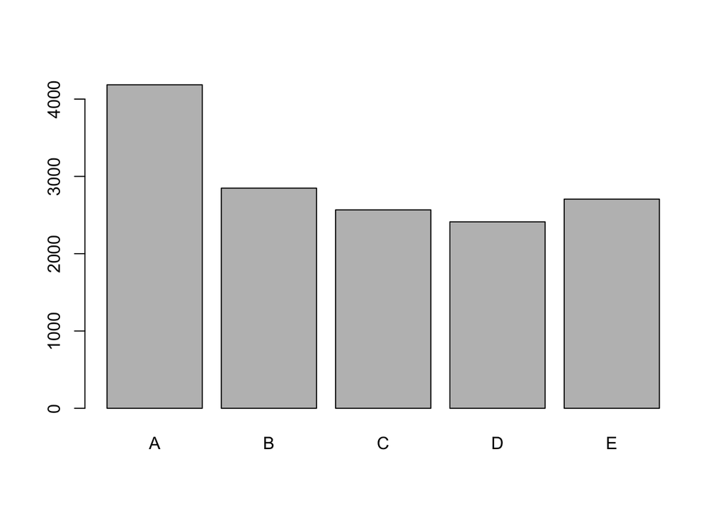

```r
plot(training$classe)
```

# Prediction

I used two different predictions to test for accuracy: linear discriminant analysis (LDA) and classification tree (CT). These models were decided based on the non-linear nature of the data.

## LDA

Below I created the LDA prediction model and obtain the accuracy of the prediction.

```r
modlda = train(classe ~ ., data = training, method = "lda")
plda = predict(modlda, testing)
confusionMatrix(plda, testing$classe)
```

```
## Confusion Matrix and Statistics
##
##           Reference
## Prediction    A    B    C    D    E
##          A 1095  153   83   58   28
##          B   35  583   67   31  150
##          C  143  130  559   92   64
##          D  112   41  118  589   85
##          E   10   42   28   34  574
##
## Overall Statistics
##
##                Accuracy : 0.6933
##                  95% CI : (0.6802, 0.7062)
##     No Information Rate : 0.2845
##     P-Value [Acc > NIR] : < 2.2e-16
##
##                   Kappa : 0.6123
##  Mcnemar's Test P-Value : < 2.2e-16
##
## Statistics by Class:
##
##                      Class: A Class: B Class: C Class: D Class: E
## Sensitivity            0.7849   0.6143   0.6538   0.7326   0.6371
## Specificity            0.9082   0.9284   0.8940   0.9132   0.9715
## Pos Pred Value         0.7728   0.6732   0.5658   0.6233   0.8343
## Neg Pred Value         0.9140   0.9094   0.9244   0.9457   0.9224
## Prevalence             0.2845   0.1935   0.1743   0.1639   0.1837
## Detection Rate         0.2233   0.1189   0.1140   0.1201   0.1170
## Detection Prevalence   0.2889   0.1766   0.2015   0.1927   0.1403
## Balanced Accuracy      0.8466   0.7714   0.7739   0.8229   0.8043
```

The accuracy of the LDA model is 0.69 (95% CI = 0.68 - 0.71), which means the expected sample out erroris 0.31.

Below I create and plot the CT prediction model and plot the classification tree.

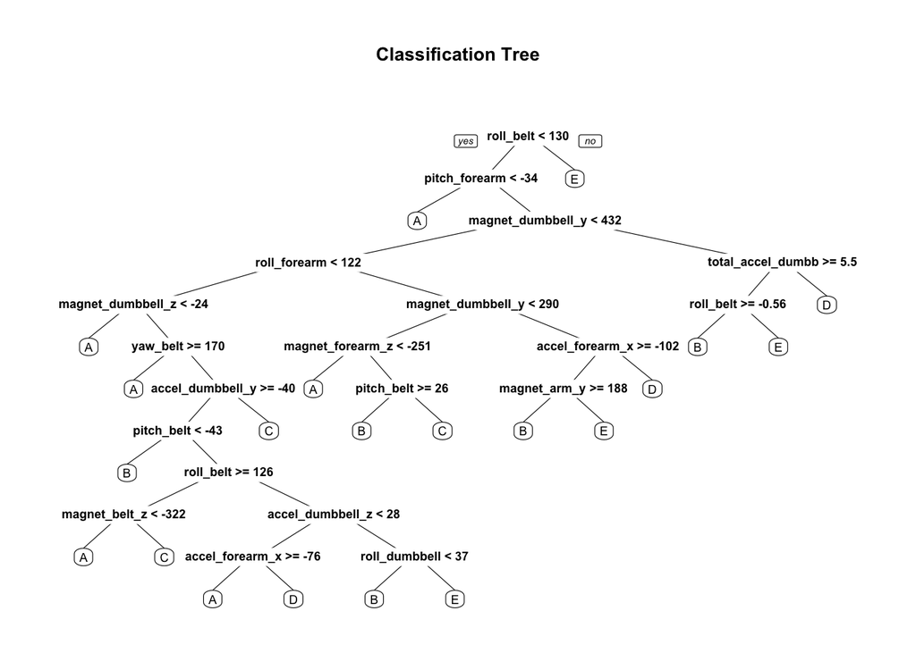

```r
modct <- rpart(classe ~ ., data=training, method="class")
rpart.plot(modct, main="Classification Tree", under=TRUE, faclen=0)
```

Next I obtain the accuracy of the CT prediction model.

```r
pct <- predict(modct, testing, type = "class")
confusionMatrix(pct, testing$classe)
```

```
## Confusion Matrix and Statistics
##
##           Reference
## Prediction    A    B    C    D    E
##          A 1280  212   70  147   41
##          B   36  556   78   44   60
##          C   27   67  628  116   98
##          D   28   62   52  402   37
##          E   24   52   27   95  665
##
## Overall Statistics
##
##                Accuracy : 0.72
##                  95% CI : (0.7072, 0.7326)
##     No Information Rate : 0.2845
##     P-Value [Acc > NIR] : < 2.2e-16
##
##                   Kappa : 0.6424
##  Mcnemar's Test P-Value : < 2.2e-16
##
## Statistics by Class:
##
##                      Class: A Class: B Class: C Class: D Class: E
## Sensitivity            0.9176   0.5859   0.7345  0.50000   0.7381
## Specificity            0.8661   0.9449   0.9239  0.95634   0.9505
## Pos Pred Value         0.7314   0.7183   0.6709  0.69191   0.7706
## Neg Pred Value         0.9635   0.9048   0.9428  0.90701   0.9416
## Prevalence             0.2845   0.1935   0.1743  0.16395   0.1837
## Detection Rate         0.2610   0.1134   0.1281  0.08197   0.1356
## Detection Prevalence   0.3569   0.1578   0.1909  0.11847   0.1760
## Balanced Accuracy      0.8918   0.7654   0.8292  0.72817   0.8443
```

# Prediction

```r
predicttest <- predict(modlda, dat_test2)
predicttest
```

```
##  [1] B A B C C E D D A A D A B A E A A B B B
## Levels: A B C D E
```

```r
pml_write_files = function(x){
        n = length(x)
        for(i in 1:n){
                files = paste0("problem_id_",i,".txt")
                write.table(x[i],file=files,col.names=FALSE,row.names=FALSE,quote=FALSE)
        }
}

pml_write_files(predicttest)
```